# Project_1_report

## Project 1 report - Mohammad Gharandouq

## Methods

Genomic assemblies were generated from Alteromonas macleodii sequencing data provided in paired-end Illumina short reads and Nanopore long reads (paths listed in bac_samples.csv). All tools were run with default parameters unless otherwise specified. The complete pipeline was implemented in Nextflow v25.04.6 and executed on the BU Shared Computing Cluster using Conda environments to ensure reproducibility.

Initial quality control of short-read data was performed using FastQC v0.12.1 with default parameters to assess read quality. Long reads were filtered with Filtlong v0.3.0 using a minimum read length of 500 bp and retaining the top 90% of reads by quality.

De novo genome assembly was carried out with Flye v2.9.6 using the filtered Nanopore reads as input. To improve assembly accuracy, Illumina short reads were aligned to the draft assembly with Bowtie2 v2.5.4 after index generation, and the resulting alignments were sorted and indexed using Samtools v1.22.1. Polishing of the draft genome was performed with Pilon v1.24 using the sorted Illumina read alignments, generating the final polished assembly.

The polished assembly was annotated with Prokka v1.14.6, which predicted protein-coding genes, rRNAs, and tRNAs. Genome completeness was evaluated using BUSCO v6.0.0 with the Alteromonas lineage dataset (alteromonas_odb12). BUSCO results were visualized using its built-in plotting utility. To benchmark assembly quality, the canonical reference genome (A. macleodii strain ATCC 27126, accession GCF_000172635.2) was downloaded using the NCBI Datasets CLI v18.6.0. Assembly quality was assessed with QUAST v5.3.0, comparing both the polished and unpolished assemblies against the reference.

## Results

### Part 1

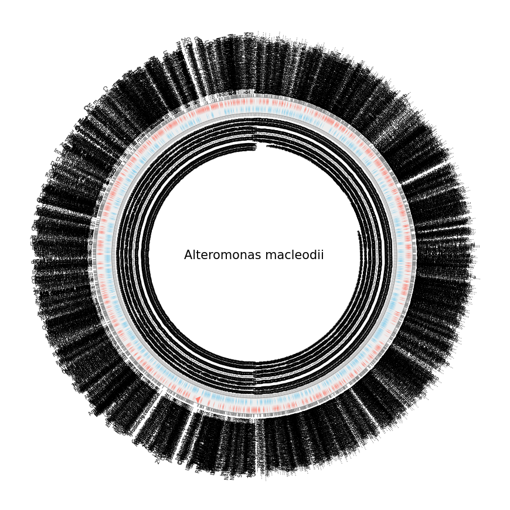

```python
from pycirclize import Circos
from pycirclize.parser import Gff
from pycirclize.utils import load_prokaryote_example_file

# Load GFF file

gff = Gff("results/annots/genome.gff")

# Initialize circos instance
seqid2size = gff.get_seqid2size()
space = 0 if len(seqid2size) == 1 else 2
circos = Circos(sectors=seqid2size, space=space)
circos.text("Alteromonas macleodii", size=15)

seqid2features = gff.get_seqid2features(feature_type="CDS")
for sector in circos.sectors:
    cds_track = sector.add_track((90, 100))
    cds_track.axis(fc="#EEEEEE", ec="none")

    features = seqid2features[sector.name]
    label_pos_list, labels = [], []
    for feature in features:
        # Plot CDS features
        if feature.location.strand == 1:
            cds_track.genomic_features(feature, plotstyle="arrow", r_lim=(95, 100), fc="salmon")
        else:
            cds_track.genomic_features(feature, plotstyle="arrow", r_lim=(90, 95), fc="skyblue")
        # Extract feature product label & position
        start, end = int(feature.location.start), int(feature.location.end)
        label_pos = (start + end) / 2
        label = feature.qualifiers.get("product", [""])[0]
        if label == "" or label.startswith("hypothetical"):
            continue
        if len(label) > 20:
            label = label[:20] + "..."
        label_pos_list.append(label_pos)
        labels.append(label)

    # Plot CDS product labels on outer position
    cds_track.xticks(
        label_pos_list,
        labels,
        label_orientation="vertical",
        show_bottom_line=True,
        label_size=6,
        line_kws=dict(ec="grey"),
    )

    # Plot xticks & intervals on inner position
    cds_track.xticks_by_interval(
        interval=5000,
        outer=False,
        show_bottom_line=True,
        label_formatter=lambda v: f"{v/ 1000:.1f} Kb",
        label_orientation="vertical",
        line_kws=dict(ec="grey"),
    )

fig = circos.plotfig()
```

### Part 2: Quast report

Genome fraction (%): 99.100

Duplication ratio: 1.014

The # of misassemblies: 23

The # of mismatches per 100kbp: 17.83

The total length of the assembly: 4653851

The GC Content: 44.71

### Part 3: Quast unpolished report

Genome fraction (%): 99.100

Duplication ratio: 1.014

The # of misassemblies: 23

The # of mismatches per 100kbp: 17.98

The total length of the assembly: 4653851

The GC Content: 44.71

##### Note any differences from the above report:

The polished and unpolished assemblies were nearly identical across all QUAST metrics. Both showed a genome fraction of 99.1%, a duplication ratio of 1.014, 23 misassemblies, and a total length of 4.65 Mb with 44.7% GC content. The only difference was a slight reduction in the mismatch rate after polishing (17.98 mismatches per 100 kbp unpolished vs. 17.83 polished), suggesting that polishing had minimal impact on this assembly.

### Part 4: BUSCO values

C:99.6%[S:99.5%,D:0.1%],F:0.0%,M:0.4%,n:1828

BUSCO (Benchmarking Universal Single-Copy Orthologs) checks how complete a genome, transcriptome, or gene set is by looking for genes that are expected to exist as single copies in almost all related organisms. It reports genes as Complete (found fully, either single-copy or duplicated), Fragmented (partially found), or Missing (not found). High percentages of complete genes mean the assembly is mostly complete, while many fragmented or missing genes suggest gaps or incomplete sequences. Duplicated genes can be real biological duplicates or assembly artifacts. Overall, BUSCO gives a quick way to measure how well your assembly represents the expected gene content.

[figure not shown]

### Part 5: Comparison of the assembled genome to the reference

The assembly of Alteromonas macleodii was highly successful, as reflected in both BUSCO and QUAST metrics. BUSCO analysis identified 1820 of 1828 (99.6%) single-copy orthologs as complete, with only 8 missing and none fragmented, indicating near-complete gene content. QUAST further supported this, reporting a genome fraction of 99.1%, showing that almost the entire reference genome is represented in the assembly. The duplication ratio of 1.014 suggests very low redundancy, and the GC content of 44.7% closely matches that of the reference genome (44.9%). While QUAST detected 23 misassemblies and an error rate of 17.8 mismatches per 100 kbp, these values are within an acceptable range for hybrid assemblies and do not substantially detract from the overall quality. The final assembly length of 4.65 Mb is consistent with the reference genome size of ~4.62 Mb (GCF_000172635.2). Together, these results demonstrate that the pipeline produced a high-quality, nearly complete genome assembly comparable to the canonical reference.